# Real Cost Measure

The Real Cost Measure was developed by advocates to capture what an annual budget looks like for a family in California meeting all of their basic needs: including food, housing, health care, child care, and transportation. Each of these need areas was elevated in conversations with First 5 LA Program Officers and Regional Network Grantees as being directly impacted or exacerbated by the pandemic, revealing the need for reforms. Using the Real Cost Measure as a framework for understanding where to target investments ensures that a holistic approach guides future planning and directly connects with needs raised by families.

Progress on this indicator helps achieve **First 5 LA’s Result: Family Resources.** The Real Cost Measure also indirectly addresses the overlap of the Impact Framework’s Child Care, Poverty, Food Insecurity, Homelessness, and Access to Transportation indicators.

# Annual Budget

**Why this matters:** The Real Cost Measure resets the baseline for what expected costs are for a family with children. While it does not capture the varying costs of living within Los Angeles County, it helps reframe the mental model around what a family’s fundamental needs and costs are.

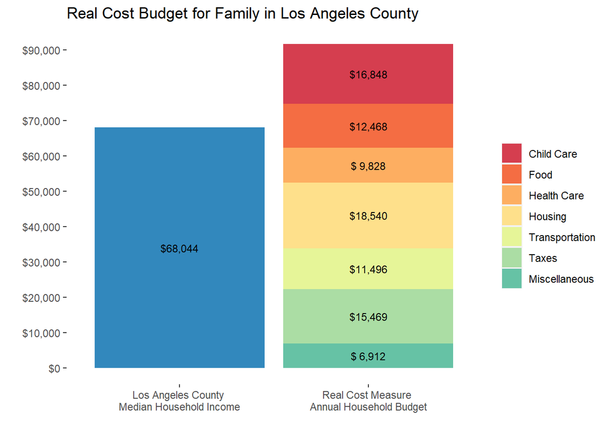

Source: Annual budget looks like for a family of two adults, one preschooler, and one school-age child living in Los Angeles County from Struggling to Stay Afloat: The Real Cost Measure in California 2019. United Ways of California. http://www.unitedwaysca.org/realcost

# Households Below Real Cost Measure

**Why this matters:** Across all 14 Best Start geographies, more than 1/3 of families earn less than enough to meet their basic needs. If we are serious about the success of LA County we must get serious about meeting the real costs of our essential workers.

[interactive chart not shown]

Struggling to Stay Afloat: The Real Cost Measure in California 2019. United Ways of California http://www.unitedwaysca.org/realcost

# Households in LA County Below Real Cost Measure by Race

**Why this matters:** Significant racial disparity exists among families who earn less than the Real Cost Measure. Over 600,000 Latinx families earn an income below the Real Cost Measure, making Latinx families the largest racial group to live on less than what’s required to meet one’s basic needs. Latinx families also make up the majority of families living in the Best Start Geographies. In total, it is not sustainable for close to 1 million Angeleno families to earn incomes below the real cost of living in LA.

[interactive chart not shown]

Struggling to Stay Afloat: The Real Cost Measure in California 2019. United Ways of California http://www.unitedwaysca.org/realcost